# SPSS_Output_lesson24

[output not shown]

Log  
Log - Log - November 19, 2017

GET  
FILE='C:\MyGithub\N736Fall2017_lesson24\helpmkh.sav'.  
DATASET NAME DataSet1 WINDOW=FRONT.  
* Encoding: UTF-8.  
* ===================================.  
* N736 - Lesson 24  
* on Reliability and Factor Analysis  
*  
* Melinda Higgins, PhD  
* dated Nov 19, 2017  
* ===================================.  
* look at the descriptive stats on the 20 CESD items  
* notice the distributions - ordinal scaling  
* notice the min and max for each item  
* check to see if any were skipped or missing  
FREQUENCIES VARIABLES=f1a f1b f1c f1d f1e f1f f1g f1h f1i f1j f1k f1l f1m f1n f1o f1p f1q f1r f1s  
f1t  
/NTILES=4  
/STATISTICS=STDDEV MINIMUM MAXIMUM MEAN  
/HISTOGRAM  
/ORDER=ANALYSIS.

Frequencies  
Frequencies - Active Dataset - November 19, 2017

[DataSet1] C:\MyGithub\N736Fall2017_lesson24\helpmkh.sav

Frequencies  
Frequencies - Statistics - November 19, 2017

StatisticsStatistics, table, 2 levels of column headers and 1 levels of row headers, table with 10 columns and 23 rows

|  | N |  | Mean | Std. Deviation | Minimum | Maximum | Percentiles |  |  |
| --- | --- | --- | --- | --- | --- | --- | --- | --- | --- |
|  | Valid | Missing |  |  |  |  | 25 | 50 | 75 |
| f1a CESD 1 - I was bothered by things that usually don't bother me | 453 | 0 | 1.63 | 1.110 | 0 | 3 | 1.00 | 2.00 | 3.00 |
| f1b CESD 2 - I did not feel like eating; my appetite was poor | 453 | 0 | 1.39 | 1.123 | 0 | 3 | .00 | 1.00 | 2.00 |
| f1c CESD 3 - I felt that I could not shake off the blues even with help from my family or friends | 453 | 0 | 1.92 | 1.093 | 0 | 3 | 1.00 | 2.00 | 3.00 |
| f1d CESD 4 - I felt that I was just as good as other people | 453 | 0 | 1.57 | 1.193 | 0 | 3 | .00 | 1.00 | 3.00 |
| f1e CESD 5 - I had trouble keeping my mind on what I was doing | 453 | 0 | 1.70 | 1.093 | 0 | 3 | 1.00 | 2.00 | 3.00 |
| f1f CESD 6 - I felt depressed | 453 | 0 | 2.02 | 1.062 | 0 | 3 | 1.00 | 2.00 | 3.00 |
| f1g CESD 7 - I felt that everything I did was an effort | 452 | 1 | 1.73 | 1.095 | 0 | 3 | 1.00 | 2.00 | 3.00 |
| f1h CESD 8 - I felt hopeful about the future | 453 | 0 | 1.48 | 1.155 | 0 | 3 | .00 | 1.00 | 3.00 |
| f1i CESD 9 - I thought my life had been a failure | 453 | 0 | 1.88 | 1.130 | 0 | 3 | 1.00 | 2.00 | 3.00 |
| f1j CESD 10 - I felt fearful | 451 | 2 | 1.53 | 1.165 | 0 | 3 | .00 | 2.00 | 3.00 |
| f1k CESD 11 - My sleep was restless | 453 | 0 | 2.04 | 1.113 | 0 | 3 | 1.00 | 2.00 | 3.00 |
| f1l CESD 12 - I was happy | 453 | 0 | 1.08 | 1.010 | 0 | 3 | .00 | 1.00 | 2.00 |
| f1m CESD 13 - I talked less than usual | 452 | 1 | 1.51 | 1.079 | 0 | 3 | 1.00 | 1.00 | 2.00 |
| f1n CESD 14 - I felt lonely | 452 | 1 | 2.01 | 1.074 | 0 | 3 | 1.00 | 2.00 | 3.00 |
| f1o CESD 15 - People were unfriendly | 453 | 0 | 1.22 | 1.122 | 0 | 3 | .00 | 1.00 | 2.00 |
| f1p CESD 16 - I enjoyed life | 452 | 1 | 1.34 | 1.137 | 0 | 3 | .00 | 1.00 | 2.00 |
| f1q CESD 17 - I had crying spells | 452 | 1 | 1.07 | 1.162 | 0 | 3 | .00 | 1.00 | 2.00 |
| f1r CESD 18 - I felt sad | 453 | 0 | 1.94 | 1.013 | 0 | 3 | 1.00 | 2.00 | 3.00 |
| f1s CESD 19 - I felt that people dislike me | 453 | 0 | 1.23 | 1.136 | 0 | 3 | .00 | 1.00 | 2.00 |
| f1t CESD 20 - I could not get going | 453 | 0 | 1.53 | 1.094 | 0 | 3 | 1.00 | 1.00 | 3.00 |

f1a CESD 1 - I was bothered by things that usually don't bother mef1a CESD 1 - I was bothered by things that usually don't bother me, table, 1 levels of column headers and 2 levels of row headers, table with 6 columns and 7 rows

|  |  | Frequency | Percent | Valid Percent | Cumulative Percent |
| --- | --- | --- | --- | --- | --- |
| Valid | 0 Not at all or less than 1 day | 90 | 19.9 | 19.9 | 19.9 |
|  | 1 1-2 days | 122 | 26.9 | 26.9 | 46.8 |
|  | 2 3-4 days | 105 | 23.2 | 23.2 | 70.0 |
|  | 3 5-7 days or nearly every day for 2 weeks | 136 | 30.0 | 30.0 | 100.0 |
|  | Total | 453 | 100.0 | 100.0 |  |

Frequency Table  
Frequency Table - f1b CESD 2 - I did not feel like eating; my appetite was poor - November 19, 2017

f1b CESD 2 - I did not feel like eating; my appetite was poorf1b CESD 2 - I did not feel like eating; my appetite was poor, table, 1 levels of column headers and 2 levels of row headers, table with 6 columns and 7 rows

|  |  | Frequency | Percent | Valid Percent | Cumulative Percent |
| --- | --- | --- | --- | --- | --- |
| Valid | 0 Not at all or less than 1 day | 131 | 28.9 | 28.9 | 28.9 |
|  | 1 1-2 days | 114 | 25.2 | 25.2 | 54.1 |
|  | 2 3-4 days | 108 | 23.8 | 23.8 | 77.9 |
|  | 3 5-7 days or nearly every day for 2 weeks | 100 | 22.1 | 22.1 | 100.0 |
|  | Total | 453 | 100.0 | 100.0 |  |

f1c CESD 3 - I felt that I could not shake off the blues even with help from my family or friendsf1c CESD 3 - I felt that I could not shake off the blues even with help from my family or friends, table, 1 levels of column headers and 2 levels of row headers, table with 6 columns and 7 rows

|  |  | Frequency | Percent | Valid Percent | Cumulative Percent |
| --- | --- | --- | --- | --- | --- |
| Valid | 0 Not at all or less than 1 day | 63 | 13.9 | 13.9 | 13.9 |
|  | 1 1-2 days | 100 | 22.1 | 22.1 | 36.0 |
|  | 2 3-4 days | 99 | 21.9 | 21.9 | 57.8 |
|  | 3 5-7 days or nearly every day for 2 weeks | 191 | 42.2 | 42.2 | 100.0 |
|  | Total | 453 | 100.0 | 100.0 |  |

Frequency Table  
Frequency Table - f1d CESD 4 - I felt that I was just as good as other people - November 19, 2017

f1d CESD 4 - I felt that I was just as good as other peoplef1d CESD 4 - I felt that I was just as good as other people, table, 1 levels of column headers and 2 levels of row headers, table with 6 columns and 7 rows

|  |  | Frequency | Percent | Valid Percent | Cumulative Percent |
| --- | --- | --- | --- | --- | --- |
| Valid | 0 Not at all or less than 1 day | 116 | 25.6 | 25.6 | 25.6 |
|  | 1 1-2 days | 115 | 25.4 | 25.4 | 51.0 |
|  | 2 3-4 days | 72 | 15.9 | 15.9 | 66.9 |
|  | 3 5-7 days or nearly every day for 2 weeks | 150 | 33.1 | 33.1 | 100.0 |
|  | Total | 453 | 100.0 | 100.0 |  |

Frequency Table  
Frequency Table - f1e CESD 5 - I had trouble keeping my mind on what I was doing - November 19, 2017

f1e CESD 5 - I had trouble keeping my mind on what I was doingf1e CESD 5 - I had trouble keeping my mind on what I was doing, table, 1 levels of column headers and 2 levels of row headers, table with 6 columns and 7 rows

|  |  | Frequency | Percent | Valid Percent | Cumulative Percent |
| --- | --- | --- | --- | --- | --- |
| Valid | 0 Not at all or less than 1 day | 85 | 18.8 | 18.8 | 18.8 |
|  | 1 1-2 days | 105 | 23.2 | 23.2 | 41.9 |
|  | 2 3-4 days | 126 | 27.8 | 27.8 | 69.8 |
|  | 3 5-7 days or nearly every day for 2 weeks | 137 | 30.2 | 30.2 | 100.0 |
|  | Total | 453 | 100.0 | 100.0 |  |

Frequency Table  
Frequency Table - f1f CESD 6 - I felt depressed - November 19, 2017

f1f CESD 6 - I felt depressedf1f CESD 6 - I felt depressed, table, 1 levels of column headers and 2 levels of row headers, table with 6 columns and 7 rows

|  |  | Frequency | Percent | Valid Percent | Cumulative Percent |
| --- | --- | --- | --- | --- | --- |
| Valid | 0 Not at all or less than 1 day | 54 | 11.9 | 11.9 | 11.9 |
|  | 1 1-2 days | 89 | 19.6 | 19.6 | 31.6 |
|  | 2 3-4 days | 105 | 23.2 | 23.2 | 54.7 |
|  | 3 5-7 days or nearly every day for 2 weeks | 205 | 45.3 | 45.3 | 100.0 |
|  | Total | 453 | 100.0 | 100.0 |  |

Frequency Table  
Frequency Table - f1g CESD 7 - I felt that everything I did was an effort - November 19, 2017

f1g CESD 7 - I felt that everything I did was an effortf1g CESD 7 - I felt that everything I did was an effort, table, 1 levels of column headers and 2 levels of row headers, table with 6 columns and 9 rows

|  |  | Frequency | Percent | Valid Percent | Cumulative Percent |
| --- | --- | --- | --- | --- | --- |
| Valid | 0 Not at all or less than 1 day | 79 | 17.4 | 17.5 | 17.5 |
|  | 1 1-2 days | 111 | 24.5 | 24.6 | 42.0 |
|  | 2 3-4 days | 115 | 25.4 | 25.4 | 67.5 |
|  | 3 5-7 days or nearly every day for 2 weeks | 147 | 32.5 | 32.5 | 100.0 |
|  | Total | 452 | 99.8 | 100.0 |  |
| Missing | System | 1 | .2 |  |  |
| Total |  | 453 | 100.0 |  |  |

Frequency Table  
Frequency Table - f1h CESD 8 - I felt hopeful about the future - November 19, 2017

f1h CESD 8 - I felt hopeful about the futuref1h CESD 8 - I felt hopeful about the future, table, 1 levels of column headers and 2 levels of row headers, table with 6 columns and 7 rows

|  |  | Frequency | Percent | Valid Percent | Cumulative Percent |
| --- | --- | --- | --- | --- | --- |
| Valid | 0 Not at all or less than 1 day | 124 | 27.4 | 27.4 | 27.4 |
|  | 1 1-2 days | 108 | 23.8 | 23.8 | 51.2 |
|  | 2 3-4 days | 100 | 22.1 | 22.1 | 73.3 |
|  | 3 5-7 days or nearly every day for 2 weeks | 121 | 26.7 | 26.7 | 100.0 |
|  | Total | 453 | 100.0 | 100.0 |  |

Frequency Table  
Frequency Table - f1i CESD 9 - I thought my life had been a failure - November 19, 2017

f1i CESD 9 - I thought my life had been a failuref1i CESD 9 - I thought my life had been a failure, table, 1 levels of column headers and 2 levels of row headers, table with 6 columns and 7 rows

|  |  | Frequency | Percent | Valid Percent | Cumulative Percent |
| --- | --- | --- | --- | --- | --- |
| Valid | 0 Not at all or less than 1 day | 75 | 16.6 | 16.6 | 16.6 |
|  | 1 1-2 days | 93 | 20.5 | 20.5 | 37.1 |
|  | 2 3-4 days | 95 | 21.0 | 21.0 | 58.1 |
|  | 3 5-7 days or nearly every day for 2 weeks | 190 | 41.9 | 41.9 | 100.0 |
|  | Total | 453 | 100.0 | 100.0 |  |

Frequency Table  
Frequency Table - f1j CESD 10 - I felt fearful - November 19, 2017

f1j CESD 10 - I felt fearfulf1j CESD 10 - I felt fearful, table, 1 levels of column headers and 2 levels of row headers, table with 6 columns and 9 rows

|  |  | Frequency | Percent | Valid Percent | Cumulative Percent |
| --- | --- | --- | --- | --- | --- |
| Valid | 0 Not at all or less than 1 day | 120 | 26.5 | 26.6 | 26.6 |
|  | 1 1-2 days | 103 | 22.7 | 22.8 | 49.4 |
|  | 2 3-4 days | 99 | 21.9 | 22.0 | 71.4 |
|  | 3 5-7 days or nearly every day for 2 weeks | 129 | 28.5 | 28.6 | 100.0 |
|  | Total | 451 | 99.6 | 100.0 |  |
| Missing | System | 2 | .4 |  |  |
| Total |  | 453 | 100.0 |  |  |

Frequency Table  
Frequency Table - f1k CESD 11 - My sleep was restless - November 19, 2017

f1k CESD 11 - My sleep was restlessf1k CESD 11 - My sleep was restless, table, 1 levels of column headers and 2 levels of row headers, table with 6 columns and 7 rows

|  |  | Frequency | Percent | Valid Percent | Cumulative Percent |
| --- | --- | --- | --- | --- | --- |
| Valid | 0 Not at all or less than 1 day | 67 | 14.8 | 14.8 | 14.8 |
|  | 1 1-2 days | 71 | 15.7 | 15.7 | 30.5 |
|  | 2 3-4 days | 94 | 20.8 | 20.8 | 51.2 |
|  | 3 5-7 days or nearly every day for 2 weeks | 221 | 48.8 | 48.8 | 100.0 |
|  | Total | 453 | 100.0 | 100.0 |  |

Frequency Table  
Frequency Table - f1l CESD 12 - I was happy - November 19, 2017

f1l CESD 12 - I was happyf1l CESD 12 - I was happy, table, 1 levels of column headers and 2 levels of row headers, table with 6 columns and 7 rows

|  |  | Frequency | Percent | Valid Percent | Cumulative Percent |
| --- | --- | --- | --- | --- | --- |
| Valid | 0 Not at all or less than 1 day | 159 | 35.1 | 35.1 | 35.1 |
|  | 1 1-2 days | 151 | 33.3 | 33.3 | 68.4 |
|  | 2 3-4 days | 89 | 19.6 | 19.6 | 88.1 |
|  | 3 5-7 days or nearly every day for 2 weeks | 54 | 11.9 | 11.9 | 100.0 |
|  | Total | 453 | 100.0 | 100.0 |  |

Frequency Table  
Frequency Table - f1m CESD 13 - I talked less than usual - November 19, 2017

f1m CESD 13 - I talked less than usualf1m CESD 13 - I talked less than usual, table, 1 levels of column headers and 2 levels of row headers, table with 6 columns and 9 rows

|  |  | Frequency | Percent | Valid Percent | Cumulative Percent |
| --- | --- | --- | --- | --- | --- |
| Valid | 0 Not at all or less than 1 day | 95 | 21.0 | 21.0 | 21.0 |
|  | 1 1-2 days | 144 | 31.8 | 31.9 | 52.9 |
|  | 2 3-4 days | 102 | 22.5 | 22.6 | 75.4 |
|  | 3 5-7 days or nearly every day for 2 weeks | 111 | 24.5 | 24.6 | 100.0 |
|  | Total | 452 | 99.8 | 100.0 |  |
| Missing | System | 1 | .2 |  |  |
| Total |  | 453 | 100.0 |  |  |

Frequency Table  
Frequency Table - f1n CESD 14 - I felt lonely - November 19, 2017

f1n CESD 14 - I felt lonelyf1n CESD 14 - I felt lonely, table, 1 levels of column headers and 2 levels of row headers, table with 6 columns and 9 rows

|  |  | Frequency | Percent | Valid Percent | Cumulative Percent |
| --- | --- | --- | --- | --- | --- |
| Valid | 0 Not at all or less than 1 day | 56 | 12.4 | 12.4 | 12.4 |
|  | 1 1-2 days | 90 | 19.9 | 19.9 | 32.3 |
|  | 2 3-4 days | 100 | 22.1 | 22.1 | 54.4 |
|  | 3 5-7 days or nearly every day for 2 weeks | 206 | 45.5 | 45.6 | 100.0 |
|  | Total | 452 | 99.8 | 100.0 |  |
| Missing | System | 1 | .2 |  |  |
| Total |  | 453 | 100.0 |  |  |

Frequency Table  
Frequency Table - f1o CESD 15 - People were unfriendly - November 19, 2017

f1o CESD 15 - People were unfriendlyf1o CESD 15 - People were unfriendly, table, 1 levels of column headers and 2 levels of row headers, table with 6 columns and 7 rows

|  |  | Frequency | Percent | Valid Percent | Cumulative Percent |
| --- | --- | --- | --- | --- | --- |
| Valid | 0 Not at all or less than 1 day | 162 | 35.8 | 35.8 | 35.8 |
|  | 1 1-2 days | 114 | 25.2 | 25.2 | 60.9 |
|  | 2 3-4 days | 93 | 20.5 | 20.5 | 81.5 |
|  | 3 5-7 days or nearly every day for 2 weeks | 84 | 18.5 | 18.5 | 100.0 |
|  | Total | 453 | 100.0 | 100.0 |  |

Frequency Table  
Frequency Table - f1p CESD 16 - I enjoyed life - November 19, 2017

f1p CESD 16 - I enjoyed lifef1p CESD 16 - I enjoyed life, table, 1 levels of column headers and 2 levels of row headers, table with 6 columns and 9 rows

|  |  | Frequency | Percent | Valid Percent | Cumulative Percent |
| --- | --- | --- | --- | --- | --- |
| Valid | 0 Not at all or less than 1 day | 137 | 30.2 | 30.3 | 30.3 |
|  | 1 1-2 days | 129 | 28.5 | 28.5 | 58.8 |
|  | 2 3-4 days | 82 | 18.1 | 18.1 | 77.0 |
|  | 3 5-7 days or nearly every day for 2 weeks | 104 | 23.0 | 23.0 | 100.0 |
|  | Total | 452 | 99.8 | 100.0 |  |
| Missing | System | 1 | .2 |  |  |
| Total |  | 453 | 100.0 |  |  |

Frequency Table  
Frequency Table - f1q CESD 17 - I had crying spells - November 19, 2017

f1q CESD 17 - I had crying spellsf1q CESD 17 - I had crying spells, table, 1 levels of column headers and 2 levels of row headers, table with 6 columns and 9 rows

|  |  | Frequency | Percent | Valid Percent | Cumulative Percent |
| --- | --- | --- | --- | --- | --- |
| Valid | 0 Not at all or less than 1 day | 204 | 45.0 | 45.1 | 45.1 |
|  | 1 1-2 days | 96 | 21.2 | 21.2 | 66.4 |
|  | 2 3-4 days | 67 | 14.8 | 14.8 | 81.2 |
|  | 3 5-7 days or nearly every day for 2 weeks | 85 | 18.8 | 18.8 | 100.0 |
|  | Total | 452 | 99.8 | 100.0 |  |
| Missing | System | 1 | .2 |  |  |
| Total |  | 453 | 100.0 |  |  |

Frequency Table  
Frequency Table - f1r CESD 18 - I felt sad - November 19, 2017

f1r CESD 18 - I felt sadf1r CESD 18 - I felt sad, table, 1 levels of column headers and 2 levels of row headers, table with 6 columns and 7 rows

|  |  | Frequency | Percent | Valid Percent | Cumulative Percent |
| --- | --- | --- | --- | --- | --- |
| Valid | 0 Not at all or less than 1 day | 40 | 8.8 | 8.8 | 8.8 |
|  | 1 1-2 days | 125 | 27.6 | 27.6 | 36.4 |
|  | 2 3-4 days | 108 | 23.8 | 23.8 | 60.3 |
|  | 3 5-7 days or nearly every day for 2 weeks | 180 | 39.7 | 39.7 | 100.0 |
|  | Total | 453 | 100.0 | 100.0 |  |

Frequency Table  
Frequency Table - f1s CESD 19 - I felt that people dislike me - November 19, 2017

f1s CESD 19 - I felt that people dislike mef1s CESD 19 - I felt that people dislike me, table, 1 levels of column headers and 2 levels of row headers, table with 6 columns and 7 rows

|  |  | Frequency | Percent | Valid Percent | Cumulative Percent |
| --- | --- | --- | --- | --- | --- |
| Valid | 0 Not at all or less than 1 day | 163 | 36.0 | 36.0 | 36.0 |
|  | 1 1-2 days | 114 | 25.2 | 25.2 | 61.1 |
|  | 2 3-4 days | 87 | 19.2 | 19.2 | 80.4 |
|  | 3 5-7 days or nearly every day for 2 weeks | 89 | 19.6 | 19.6 | 100.0 |
|  | Total | 453 | 100.0 | 100.0 |  |

Frequency Table  
Frequency Table - f1t CESD 20 - I could not get going - November 19, 2017

f1t CESD 20 - I could not get goingf1t CESD 20 - I could not get going, table, 1 levels of column headers and 2 levels of row headers, table with 6 columns and 7 rows

|  |  | Frequency | Percent | Valid Percent | Cumulative Percent |
| --- | --- | --- | --- | --- | --- |
| Valid | 0 Not at all or less than 1 day | 96 | 21.2 | 21.2 | 21.2 |
|  | 1 1-2 days | 139 | 30.7 | 30.7 | 51.9 |
|  | 2 3-4 days | 100 | 22.1 | 22.1 | 74.0 |
|  | 3 5-7 days or nearly every day for 2 weeks | 118 | 26.0 | 26.0 | 100.0 |
|  | Total | 453 | 100.0 | 100.0 |  |

Histogram  
Histogram - CESD 1 - I was bothered by things that usually don't bother me - November 19, 2017

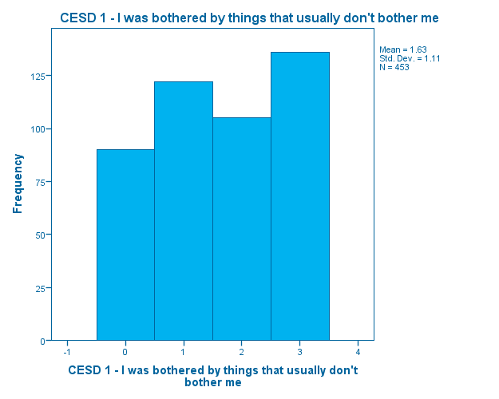

Histogram  
Histogram - CESD 2 - I did not feel like eating; my appetite was poor - November 19, 2017

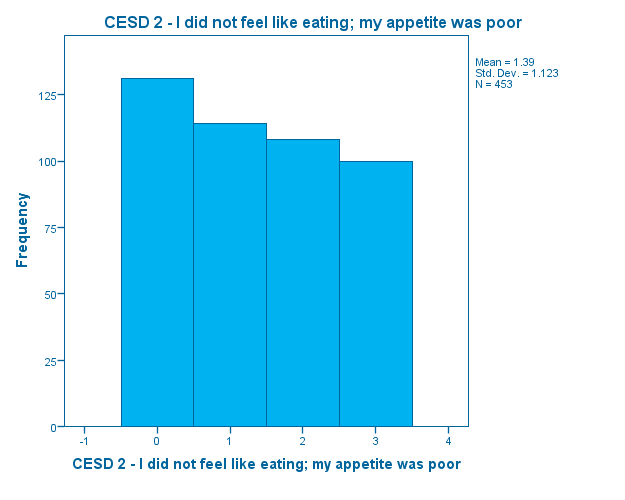

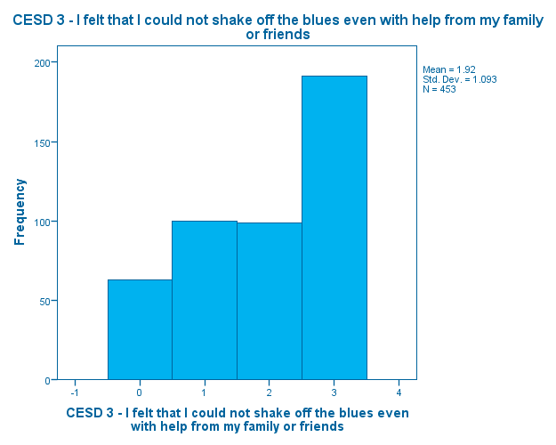

Histogram  
Histogram - CESD 4 - I felt that I was just as good as other people - November 19, 2017

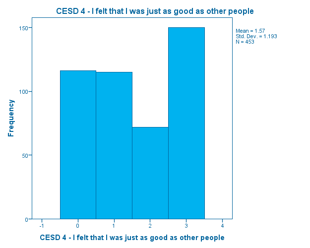

Histogram  
Histogram - CESD 5 - I had trouble keeping my mind on what I was doing - November 19, 2017

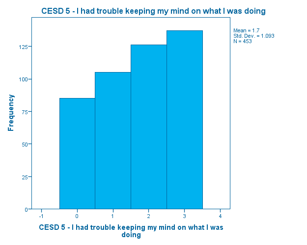

Histogram  
Histogram - CESD 6 - I felt depressed - November 19, 2017

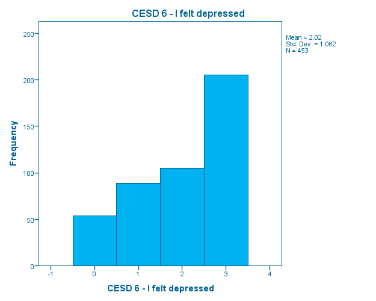

Histogram  
Histogram - CESD 7 - I felt that everything I did was an effort - November 19, 2017

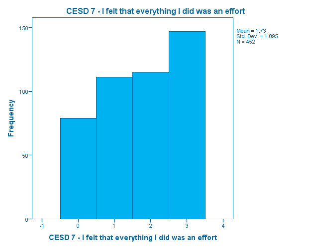

Histogram  
Histogram - CESD 8 - I felt hopeful about the future - November 19, 2017

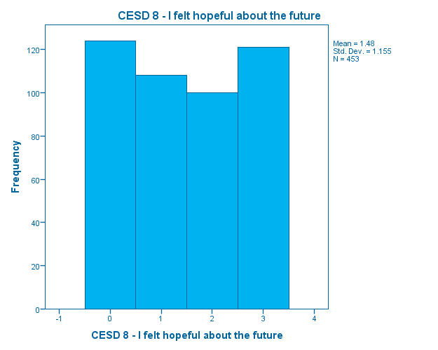

Histogram  
Histogram - CESD 9 - I thought my life had been a failure - November 19, 2017

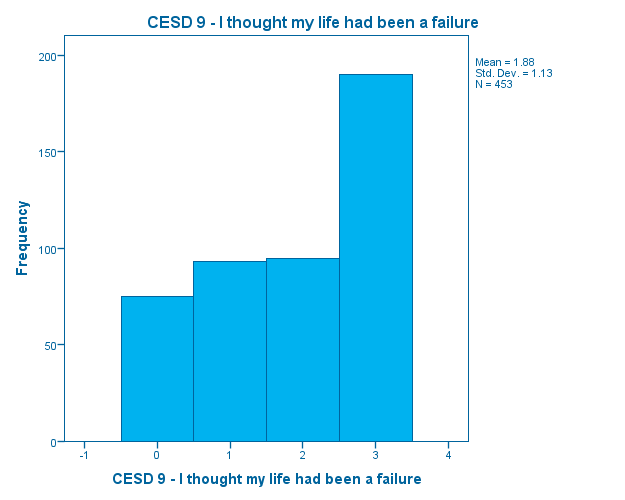

Histogram  
Histogram - CESD 10 - I felt fearful - November 19, 2017

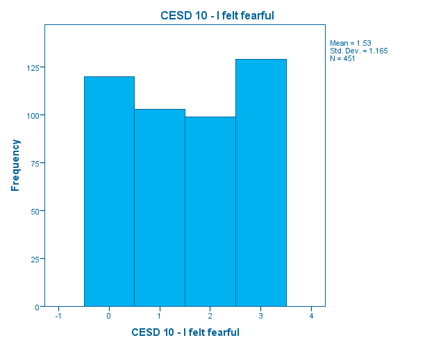

Histogram  
Histogram - CESD 11 - My sleep was restless - November 19, 2017

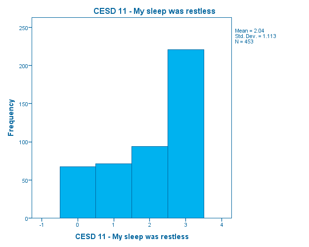

Histogram  
Histogram - CESD 12 - I was happy - November 19, 2017

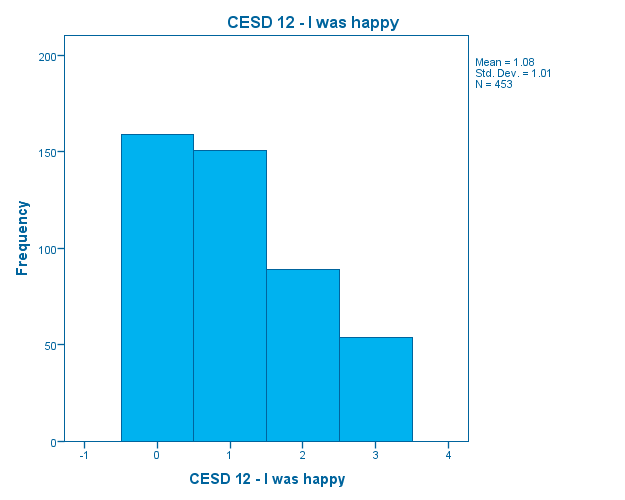

Histogram  
Histogram - CESD 13 - I talked less than usual - November 19, 2017

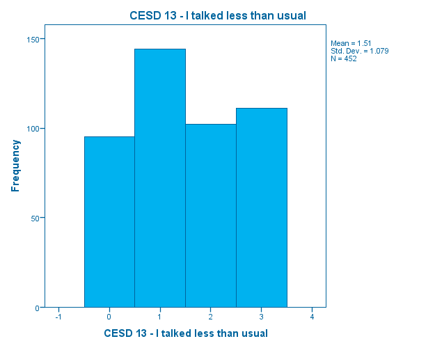

Histogram  
Histogram - CESD 14 - I felt lonely - November 19, 2017

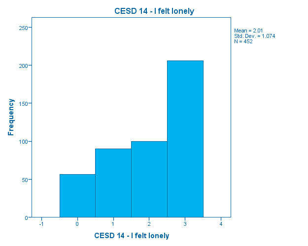

Histogram  
Histogram - CESD 15 - People were unfriendly - November 19, 2017

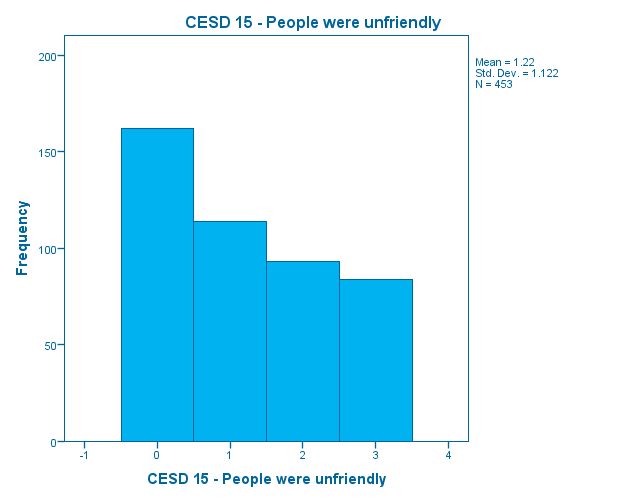

Histogram  
Histogram - CESD 16 - I enjoyed life - November 19, 2017

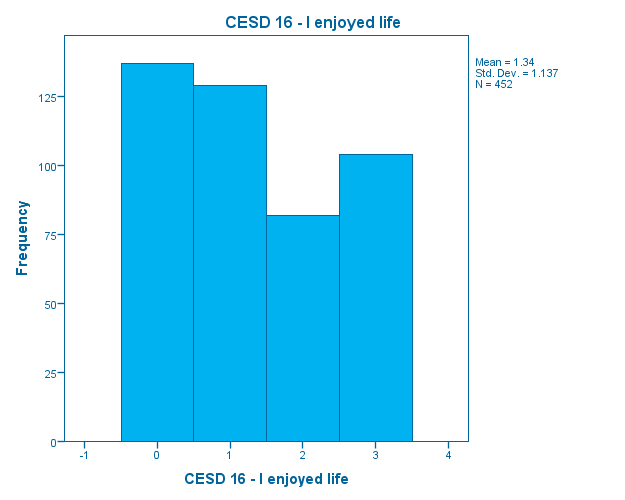

Histogram  
Histogram - CESD 17 - I had crying spells - November 19, 2017

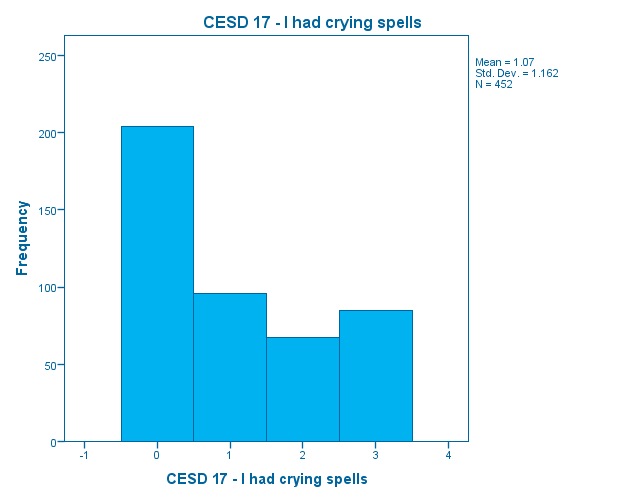

Histogram  
Histogram - CESD 18 - I felt sad - November 19, 2017

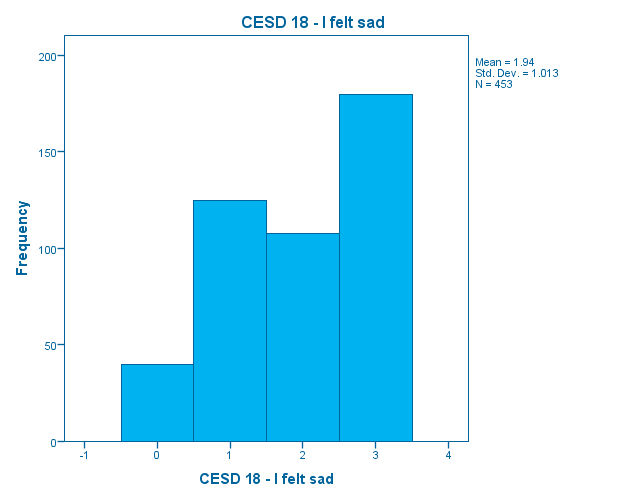